# A Forecasting Framework for Predicting Perceived Fatigue: Using Time Series Methods to Forecast Ratings of Perceived Exertion with Features from Wearable Sensors

### 3-ahead

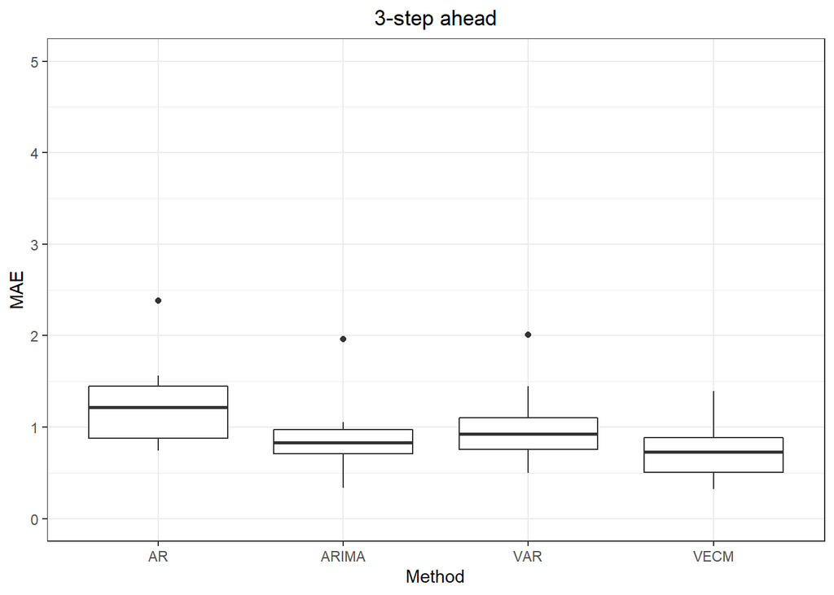

### 4-ahead

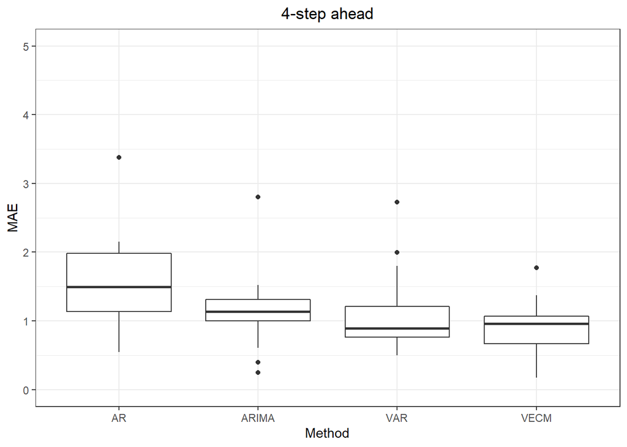

### 5-ahead

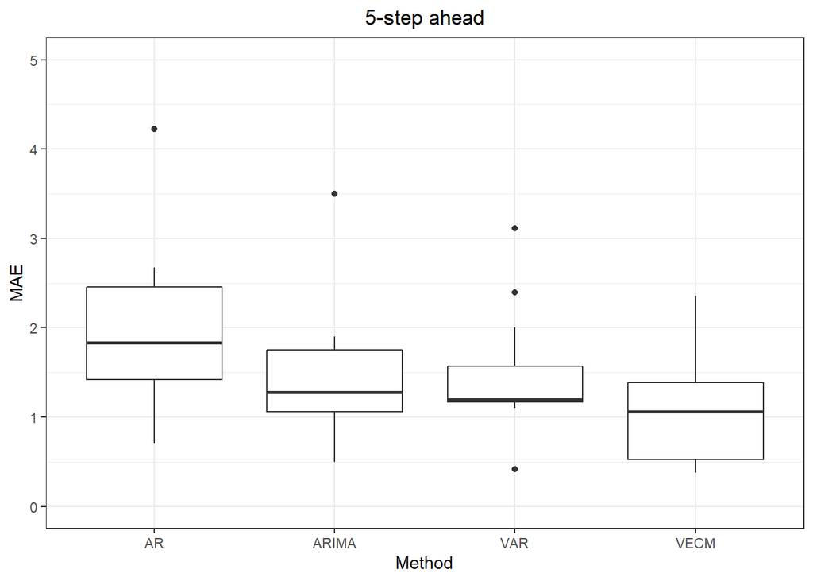

### 6-ahead

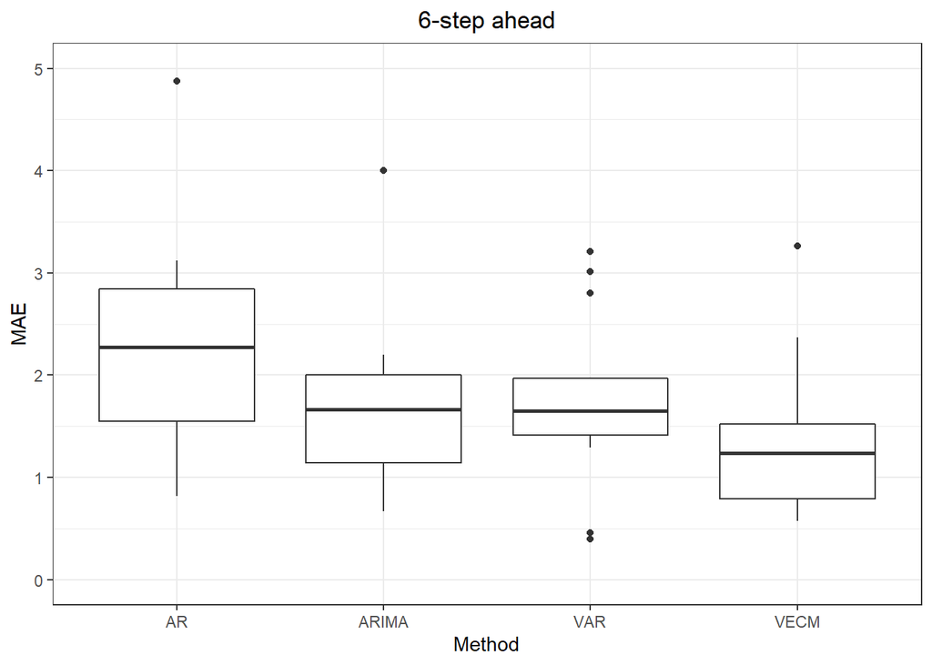

## 5.2 MAE Bar-plots

```r
final_sub_range = c(1,3,4,5,7,8,9,10,11,12,13,14,15)
for (num_subject in final_sub_range) {
cat(paste0("### Participant ",num_subject, " {-} \n"))
df = data.frame(MAE = c(AR_MAE[,num_subject],VAR_MAE[,num_subject],VECM_MAE[,num_subject],ARIMA_MAE[,num_subject]),k_step_ahead = rep(sprintf("%s_step ahead",n_ahead_range),4),Method = c(rep("AR",length(n_ahead_range)),rep("VAR",length(n_ahead_range)),rep("VECM",length(n_ahead_range)),rep("ARIMA",length(n_ahead_range))))
p = ggplot(df, aes(Method, MAE)) + geom_col() + facet_wrap(~k_step_ahead,scales = "free")+theme_bw()+ ggtitle(paste0("Participant ",toString(num_subject)))+ theme(plot.title = element_text(hjust = 0.5))
print(p)
  cat("\n \n")
}
```

### Participant 1

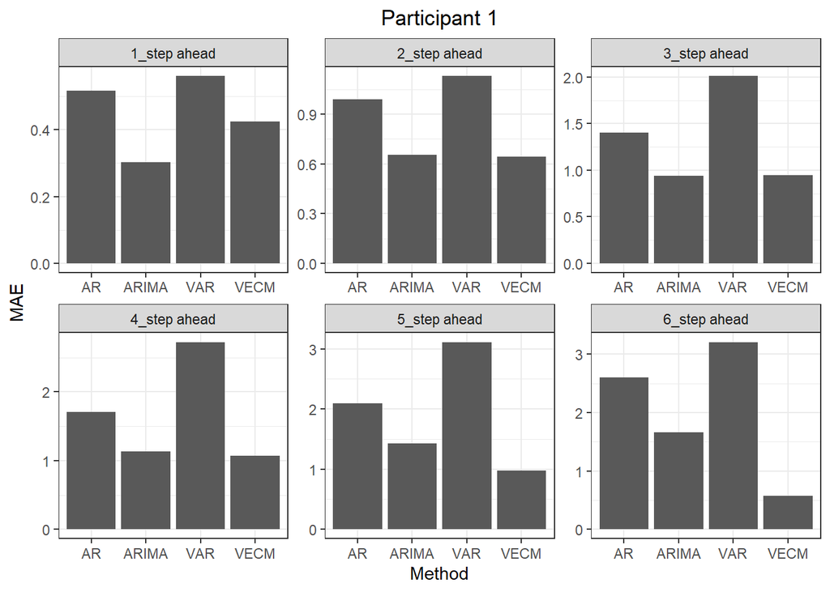

### Participant 3

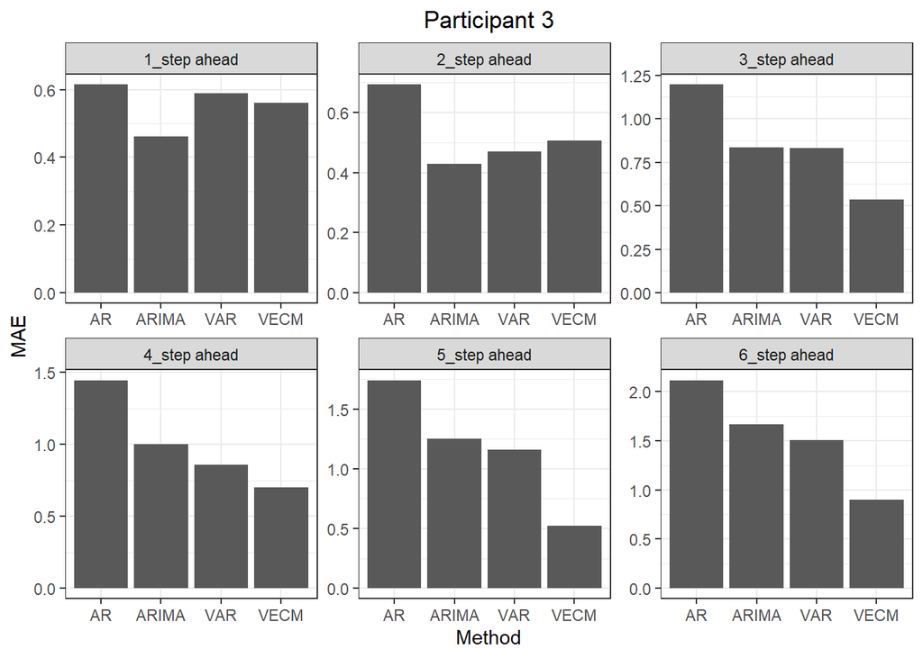

### Participant 4

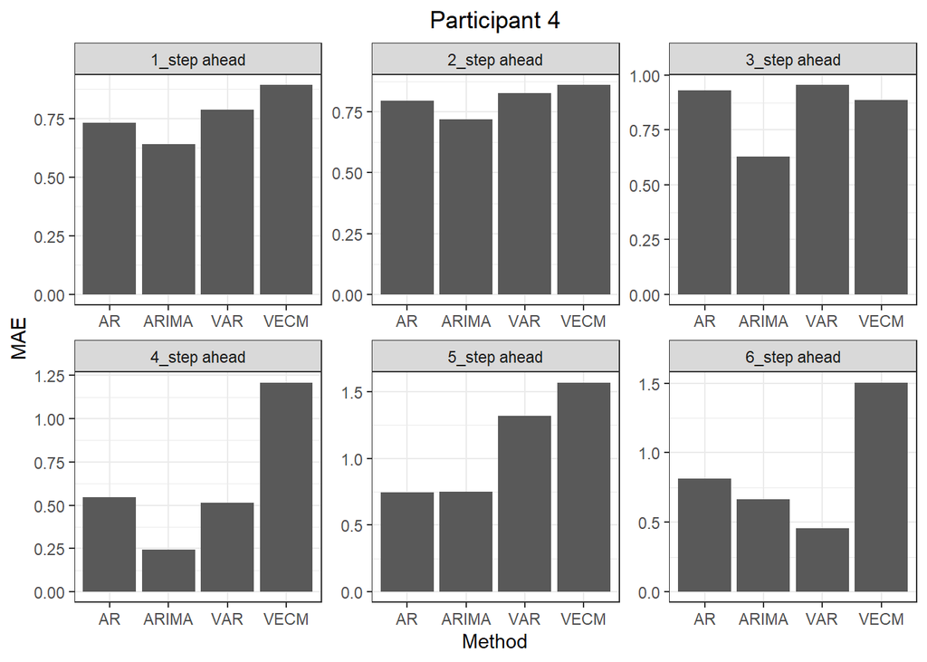

### Participant 5

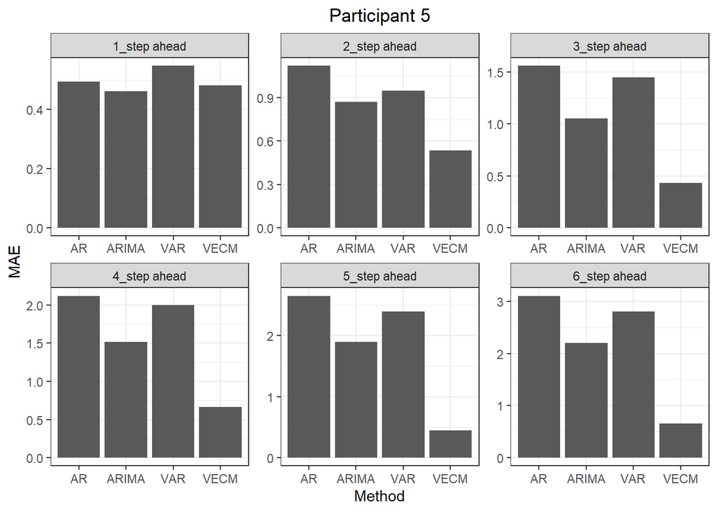

### Participant 7

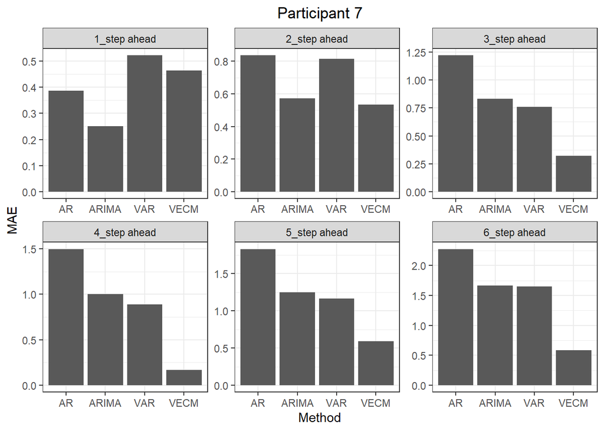

### Participant 8

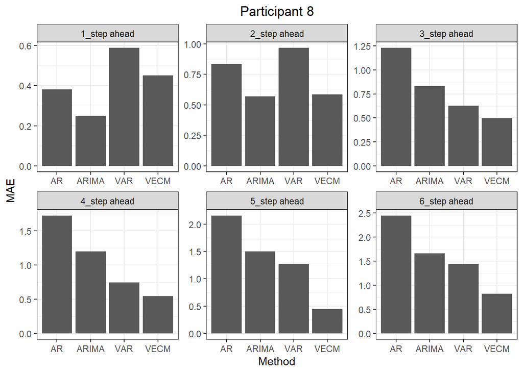

### Participant 9

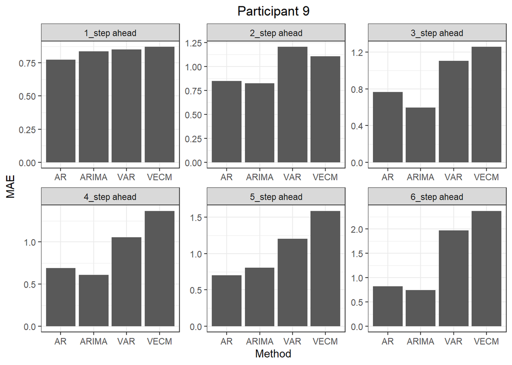

### Participant 10

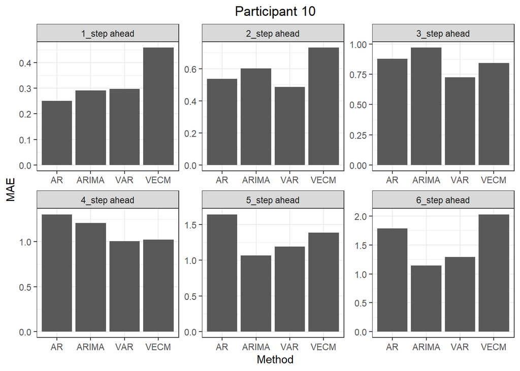

### Participant 11

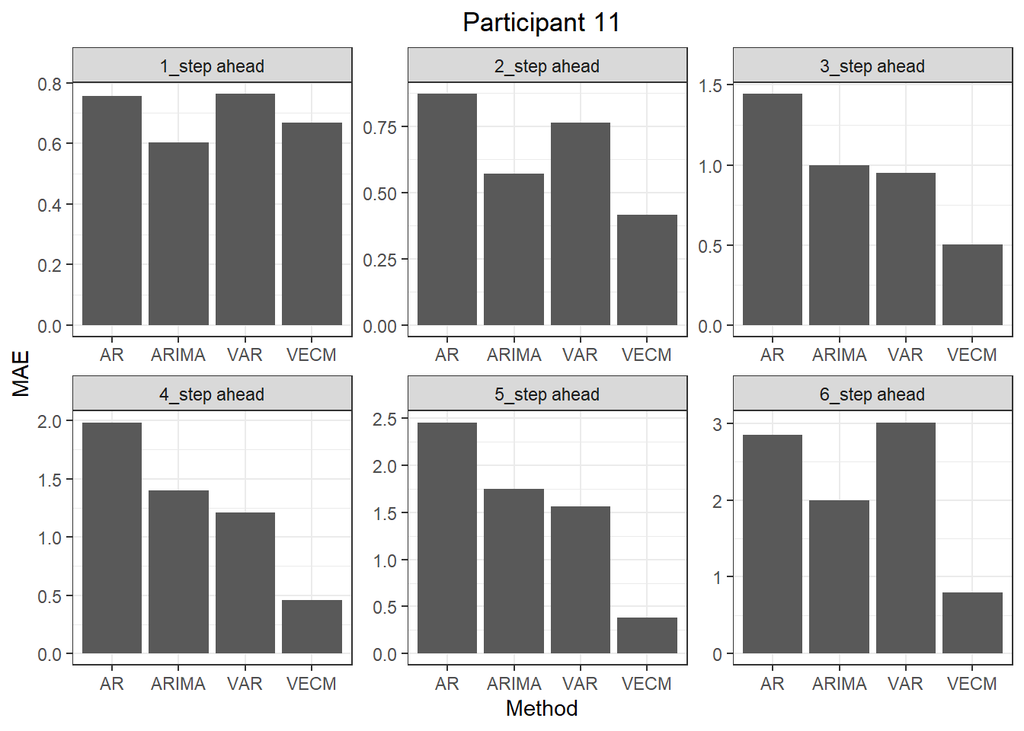

### Participant 12

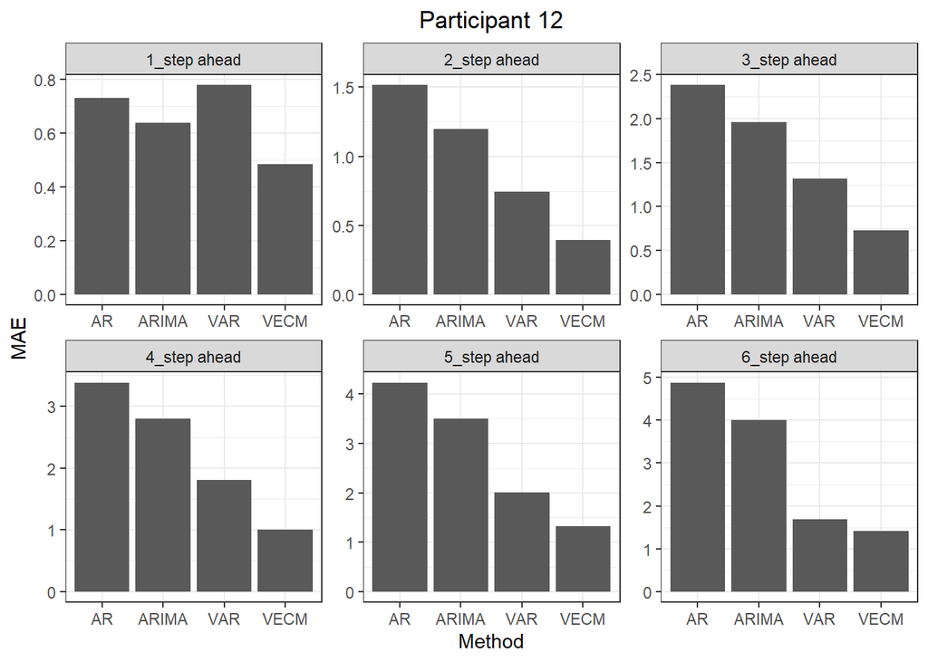

### Participant 13

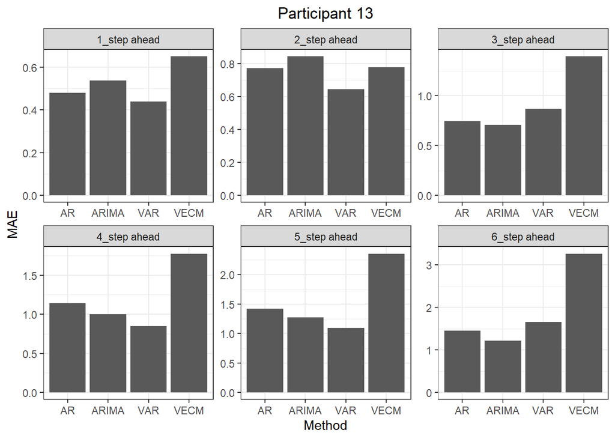

### Participant 14

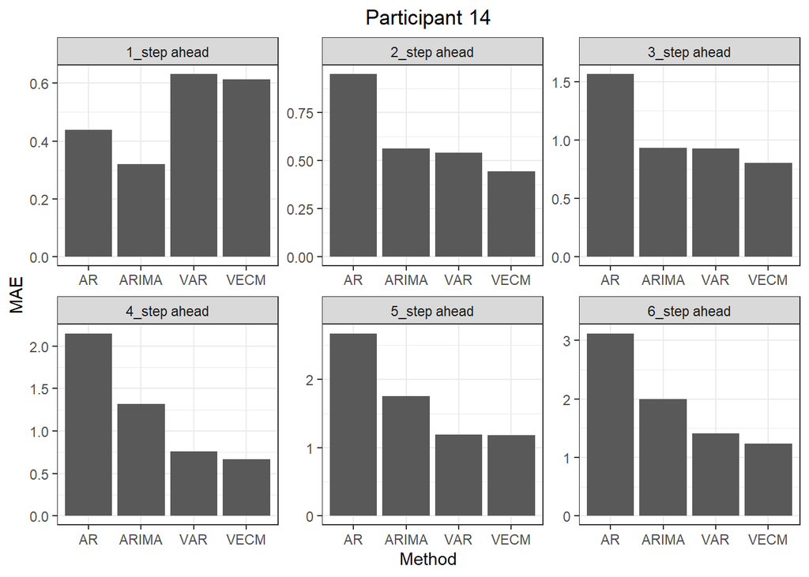

### Participant 15

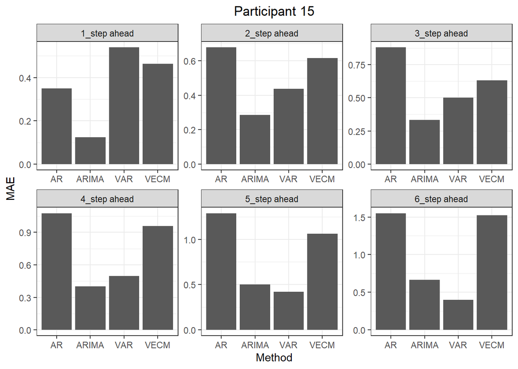

# 6 Overall MAE Results

In this section, we get the median MAE for different participants.

```r
AR_Overall = apply(AR_MAE[,c(-2,-6)],1,median)
ARIMA_Overall = apply(ARIMA_MAE[,c(-2,-6)],1,median)
VAR_Overall = apply(VAR_MAE[,c(-2,-6)],1,median)
VECM_Overall = apply(VECM_MAE[,c(-2,-6)],1,median)
Overall_MAE = rbind(AR_Overall,ARIMA_Overall,VAR_Overall,VECM_Overall)
print(Overall_MAE)
```

```
##                 1_ahead   2_ahead   3_ahead   4_ahead  5_ahead  6_ahead
## AR_Overall    0.4946520 0.8359781 1.2198418 1.4962388 1.831497 2.274216
## ARIMA_Overall 0.4619919 0.6017053 0.8333333 1.1363935 1.276622 1.666667
## VAR_Overall   0.5880567 0.7635780 0.9253968 0.8900874 1.198960 1.648872
## VECM_Overall  0.4841007 0.5852558 0.7269426 0.9578534 1.063142 1.238339
```

# 7 Save the Results

This code-chunk saves the Johansent Test, MAE and forecast results.

```r
save(AR_MAE,VAR_MAE,VECM_MAE,ARIMA_MAE,file = "MAE Results.Rdata")
save(Overall_MAE,file = "Overall MAE.Rdata")
save(AR_Results,VAR_Results,VECM_Results,ARIMA_Results,file = "Forecast Results.Rdata")
save(Jotest_Sub_1,Jotest_Sub_2,Jotest_Sub_3,Jotest_Sub_4,Jotest_Sub_5,Jotest_Sub_6,Jotest_Sub_7,Jotest_Sub_8,Jotest_Sub_9,Jotest_Sub_10,Jotest_Sub_11,Jotest_Sub_12,Jotest_Sub_13,Jotest_Sub_14,Jotest_Sub_15,file = "Jotest_Results.Rdata")
```

# References

Baghdadi, Amir, Lora A Cavuoto, Allison Jones-Farmer, Steven E Rigdon, Ehsan T Esfahani, and Fadel M Megahed. 2019. “Monitoring Worker Fatigue Using Wearable Devices: A Case Study to Detect Changes in Gait Parameters.” *Journal of Quality Technology*.

Baghdadi, Amir, Fadel M Megahed, Ehsan T Esfahani, and Lora A Cavuoto. 2018. “A Machine Learning Approach to Detect Changes in Gait Parameters Following a Fatiguing Occupational Task.” *Ergonomics* 61 (8): 1116–29.

Di Narzo, Antonio Fabio, Jose Luis Aznarte, and Matthieu Stigler. 2015. “Package ’tsDyn’.”

Lütkepohl, Helmut. 2005. *New Introduction to Multiple Time Series Analysis*. Springer Science & Business Media.

[^1]: Email: sahandha@buffalo.edu
[^2]: Email: hongyues@buffalo.edu | Phone: +1-716-645-4715 | Website: [University at Buffalo Official](http://engineering.buffalo.edu/industrial-systems/people/faculty-directory/sun-hongyue.html)
[^3]: Email: megahefm@miamioh.edu | Phone: +1-513-529-4185 | Website: [Miami University Official](https://miamioh.edu/fsb/directory/?up=/directory/megahefm)
[^4]: Email: farmerl2@miamioh.edu | Phone: +1-513-529-4823 | Website: [Miami University Official](https://miamioh.edu/fsb/directory/?up=/directory/farmerl2)
[^5]: Email: loracavu@buffalo.edu | Phone: +1-716-645-4696 | Website: [University at Buffalo Official](http://engineering.buffalo.edu/industrial-systems/people/faculty-directory/cavuoto-lora.html)